# HotellingEllipse

Christian L. Goueguel

This package is specifically designed to help draw Hotelling’s T-squared ellipses on PCA or PLS score scatterplots, a crucial tool in chemometrics for multivariate data analysis and quality control. In the field of chemometrics, these ellipses serve as powerful visual aids for measurements assessment, outlier detection, and process monitoring. By superimposing Hotelling’s T-squared ellipses onto score plots, analysts can quickly identify abnormal samples and establish well-defined confidence regions for normal process operations.

The package’s functionality enables computing the Hotelling’s T-squared statistic, the semi-minor and semi-major axes of the Hotelling’s T-squared ellipse, and generates the coordinate points necessary for constructing a confidence ellipse. Specifically, the package provides two primary functions:

- `ellipseParam()`, is used to calculate the Hotelling’s T-squared statistic and the semi-axes of the confidence ellipses at 99% and 95% confidence intervals.
- `ellipseCoord()`, is primarily used to get the *x*, *y*, and *z* coordinates for plotting 2D or 3D confidence ellipses at user-defined confidence interval. The confidence interval is set at 95% by default.

# Data

```r
library(HotellingEllipse)
```

```r
data("specData", package = "HotellingEllipse")
```

# Principal component analysis

In this example, we use `FactoMineR::PCA()` to perform the Principal Component Analysis (PCA) on a LIBS spectral dataset `specData`, and extract the PCA scores.

```r
set.seed(002)
pca_mod <- specData %>%
  select(where(is.numeric)) %>%
  PCA(scale.unit = FALSE, graph = FALSE)
```

```r
pca_scores <- pca_mod %>%
  pluck("ind", "coord") %>%
  as_tibble() %>%
  print()
```

```
#> # A tibble: 100 × 5
#>      Dim.1    Dim.2  Dim.3   Dim.4 Dim.5
#>      <dbl>    <dbl>  <dbl>   <dbl> <dbl>
#>  1 25306.  -10831.  -1851.   -83.4 -560.
#>  2   -67.3   1137.  -2946.  2495.  -568.
#>  3 -1822.     -22.0 -2305.  1640.  -409.
#>  4 -1238.    3734.   4039. -2428.   379.
#>  5  3299.    4727.   -888. -1089.   262.
#>  6  5006.     -49.5  2534.  1917.  -970.
#>  7 -8325.   -5607.    960. -3361.   103.
#>  8 -4955.   -1056.   2510.  -397.  -354.
#>  9 -1610.    1271.  -2556.  2268.  -760.
#> 10 19582.    2289.    886.  -843.  1483.
#> # ℹ 90 more rows
```

# Hotelling’s T-Squared Statistic

The Hotelling’s T-squared statistic can be computed using the `ellipseParam` function in two distinct ways. (1) By specifying the parameter `k`: This represents the number of principal components to retain. (2) By setting the `threshold` parameter: This defines the cumulative explained variance to determine the number of components.

The function also returns the 95% and 99% cutoffs (`cutoff.95pct` and `cutoff.99pct`), on the same scale as the T-squared values. By default (`method = "f"`), they are based on the F distribution, as in previous versions of the package. Setting `method = "beta"` uses the exact distribution of T-squared for the observations used to build the model (e.g. the PCA scores themselves), which is less conservative for small sample sizes.

The confidence levels are set with `conf.limit` (default `c(0.95, 0.99)`). Any number of levels can be given, and the cutoffs are named after them:

```r
res <- ellipseParam(pca_scores, k = 3, conf.limit = c(0.975, 0.999))
res$cutoff.97.5pct
```

```
#> [1] 9.962844
```

```r
res$cutoff.99.9pct
```

```
#> [1] 17.97598
```

## Calculate using the first k components

```r
T2 <- ellipseParam(pca_scores, k = 3)$Tsquare$value
```

```r
T2
```

```
#>   [1] 26.9359912  1.3035681  0.8181310  3.4524888  2.2601156  1.5363946
#>   [7]  4.5589523  1.5997599  1.1021269 10.5176373  6.7530504  0.4490389
#>  [13]  3.7666788  3.3125399  0.1961058  2.5214647 12.6176330  0.5787373
#>  [19]  2.2944640  5.5476646  3.1043351  1.1121461  0.5572901  3.6615960
#>  [25]  2.5225895  1.8064956  5.0332286  4.1342302  0.1235691  3.2825330
#>  [31]  4.1423800  2.7338459  1.7932333  1.5642370  1.0274836  1.0815384
#>  [37]  8.4494300  2.2507997  1.2889658  2.0055085  1.2579481  0.8129788
#>  [43]  1.4767197  1.1037556  0.7726731  2.3574590  8.9937441  0.2192175
#>  [49]  0.4696003  0.2927783  0.3801802  1.2736893  1.1779661  0.6704998
#>  [55]  0.6387191  3.8626352  0.8080024  4.1404653  0.1770208  1.9932766
#>  [61]  8.0189602  2.8796440  4.9259458  3.1282834  1.2640104  0.8339147
#>  [67]  0.4548289  2.0397243  8.6515819  0.3914797  3.8373333  2.0394326
#>  [73]  3.7615098  3.4694532  4.4967707  4.4755532  0.3195505  0.7962801
#>  [79]  2.9739205  5.8796332  5.9977360  1.1048693 14.8436772  0.7567167
#>  [85]  1.7061799  1.9620665  5.7476742  0.4408659  1.5325019  1.3374305
#>  [91]  2.3335374  1.7798649  4.5409529  1.7054550  0.5269098  0.3396184
#>  [97]  2.3394461  2.0299035  0.3605003  4.2989752
```

```r
T2 <- ellipseParam(pca_scores, k = 5)$Tsquare$value
```

```r
T2
```

```
#>   [1] 27.8866342  4.1936320  2.1509400  5.7001214  2.8322982  5.5162077
#>   [7]  8.0637351  2.0285897  4.4333479 17.4031018  6.9644785 13.9301333
#>  [13]  7.5058872  3.8846854  0.5062559  3.3187398 15.8350981  0.7569473
#>  [19]  8.6480718 10.5790510  3.5861798  3.6849770  5.4944820  4.9640133
#>  [25]  3.5138375  2.7007476  8.3540353  8.6112244  2.4387450  8.4032224
#>  [31]  4.7203033  4.3622686  3.0041681  6.6657572  2.1274971  1.3322277
#>  [37] 10.0430974  2.2752622  2.1911724  2.7967066  1.7364953  1.6422900
#>  [43]  2.7834955  1.4618938  2.0501029  6.8495777 12.2435176  1.1245962
#>  [49]  1.0141455  0.3386685  3.9819865  4.2906927  3.1519901  1.3256422
#>  [55]  2.3357067  3.9206974  4.4032602  5.0987662  1.3096467  3.5706471
#>  [61] 11.8097827  8.3291020  5.8580741  4.4016612  1.3194074  2.3346407
#>  [67]  3.8915050  2.3912379 14.6666902  2.5581055  4.2157923  3.0072090
#>  [73]  4.0293216  3.8885664  9.6359306  4.6290423  2.4385853  1.7703987
#>  [79]  3.0275634  7.0449976  9.0552538  2.7086513 15.1762910  1.0669176
#>  [85]  3.6658740  2.8797799  8.5114570  1.2726549  2.9011409  9.7148287
#>  [91]  2.3903410  2.0714626  5.1307896  2.8887764  1.0914762  3.2900669
#>  [97]  3.7004230  2.7003051  0.8944171  4.5997790
```

## Calculate using the cumulative variance threshold

```r
T2 <- ellipseParam(pca_scores, threshold = 0.80)$Tsquare$value
```

```r
T2
```

```
#>   [1] 26.464068265  0.108209302  0.086398749  1.205943415  2.151631740
#>   [6]  0.651853092  4.431944033  0.731794753  0.202585969 10.409551360
#>  [11]  0.275738260  0.378398534  0.923363502  1.690265623  0.076672352
#>  [16]  1.009038659 12.530163311  0.573671832  2.128055230  4.396597843
#>  [21]  3.020620830  0.663245787  0.002176855  0.779342541  1.555746416
#>  [26]  1.727649890  3.876177671  3.835451686  0.120680714  3.120680543
#>  [31]  4.105956600  2.700655741  1.482889622  0.388858992  0.383616196
#>  [36]  0.462205410  5.078749027  0.460334171  1.205433816  1.604310326
#>  [41]  1.170967856  0.364674800  0.758265279  0.205593631  0.586825789
#>  [46]  2.327331675  1.245242519  0.032864362  0.466451354  0.052623976
#>  [51]  0.366867389  0.378203951  0.642683833  0.099612343  0.609298506
#>  [56]  3.736657076  0.188623056  0.683422150  0.110526579  1.749413356
#>  [61]  6.908594798  1.883878309  2.754553363  1.758131531  1.036442249
#>  [66]  0.151756955  0.032743153  0.394939357  8.054311493  0.288424965
#>  [71]  0.766490722  1.635166226  3.757903444  0.117999060  3.956614432
#>  [76]  0.122530713  0.266348169  0.315141319  1.478046932  5.463185721
#>  [81]  0.492414078  1.104132927 13.970325155  0.747450514  0.860615813
#>  [86]  0.761276399  0.081409537  0.296670901  1.058911121  1.317953773
#>  [91]  0.026998583  0.646018874  3.976456355  1.473992350  0.432538296
#>  [96]  0.189591196  1.854698388  0.320799487  0.180273734  4.287391469
```

```r
T2 <- ellipseParam(pca_scores, threshold = 0.95)$Tsquare$value
```

```r
T2
```

```
#>   [1] 26.9381268  3.2169190  1.6448712  5.2648988  2.6244806  2.6656514
#>   [7]  8.0316358  1.6481669  2.6824005 10.7361403  6.9620914  9.6456056
#>  [13]  7.1621381  3.6773853  0.3776425  2.5326108 15.4604164  0.6102036
#>  [19]  4.7890695  5.6596520  3.1045948  3.0580112  1.6465983  4.8829743
#>  [25]  3.4824536  2.0328461  8.3430319  4.5152598  0.3956586  3.9765548
#>  [31]  4.2219666  4.3568589  2.4048116  5.2308083  2.1267403  1.1165385
#>  [37]  9.9715652  2.2508076  1.9449361  2.3130620  1.5220412  1.6205224
#>  [43]  2.1527381  1.1039826  1.9800376  4.1666747 10.5100740  0.6782320
#>  [49]  0.4706103  0.3194839  3.6926836  4.2054587  2.4450730  1.0673555
#>  [55]  2.0844898  3.8828201  4.3998334  5.0002251  0.5499455  2.0458777
#>  [61] 10.3019581  4.3314450  4.9855572  3.3904810  1.3190731  1.5055651
#>  [67]  3.7545395  2.0850202  8.7978821  1.1232330  3.8757571  3.0033730
#>  [73]  3.8808399  3.6808528  4.6261163  4.6285946  2.3974539  1.0031227
#>  [79]  2.9991345  7.0295524  6.5636125  1.1075652 15.1529327  1.0495245
#>  [85]  3.1239319  1.9896620  8.0144973  0.4766796  1.5651052  4.9673490
#>  [91]  2.3497828  1.8787426  4.6196904  2.3635573  0.6168596  3.1218809
#>  [97]  3.6942089  2.0470524  0.6050035  4.3684657
```

# Hotelling’s T-Squared Ellipse

## Calculating the semi-axes

To visualize the confidence region for our multivariate data, we employ the `ellipseParam()` function to generate a confidence ellipse. Our objective is to calculate the lengths of the semi-axes for this ellipse, focusing on the bivariate relationship within the PC1-PC3 subspace of our principal component analysis. We maintain the default value for `k` (number of components) at 2. This ensures we’re working with a two-dimensional representation. We specify `pcx = 1` and `pcy = 3` as inputs. This directs the function to use the 1st and 3rd principal components for the *x* and *y* axes, respectively. The Hotelling’s T-squared statistic returned in `Tsquare` is computed on these same two components, so an observation lies outside the ellipse exactly when its T-squared value exceeds the corresponding cutoff.

```r
ellipse_axes <- ellipseParam(pca_scores, pcx = 1, pcy = 3)
```

```r
str(ellipse_axes)
```

```
#> List of 5
#>  $ Tsquare     : tibble [100 × 1] (S3: tbl_df/tbl/data.frame)
#>   ..$ value: num [1:100] 17.124 1.195 0.818 2.286 0.392 ...
#>  $ cutoff.99pct: num 9.76
#>  $ cutoff.95pct: num 6.24
#>  $ nb.comp     : int 2
#>  $ Ellipse     : tibble [1 × 5] (S3: tbl_df/tbl/data.frame)
#>   ..$ a.99pct: num 19369
#>   ..$ b.99pct: num 8416
#>   ..$ a.95pct: num 15492
#>   ..$ b.95pct: num 6732
#>   ..$ angle  : num 0
```

We can extract parameters for further use:

- Semi-axes of the ellipse at 99% confidence level.

```r
a1 <- ellipse_axes %>% pluck("Ellipse", "a.99pct")
b1 <- ellipse_axes %>% pluck("Ellipse", "b.99pct")
```

- Semi-axes of the ellipse at 95% confidence level.

```r
a2 <- ellipse_axes %>% pluck("Ellipse", "a.95pct")
b2 <- ellipse_axes %>% pluck("Ellipse", "b.95pct")
```

- Hotelling’s T$^2$ statistic.

```r
Tsq <- ellipse_axes %>% pluck("Tsquare", "value")
```

```r
t1 <- round(as.numeric(pca_mod$eig[1,2]), 2)
t2 <- round(as.numeric(pca_mod$eig[2,2]), 2)
t3 <- round(as.numeric(pca_mod$eig[3,2]), 2)
```

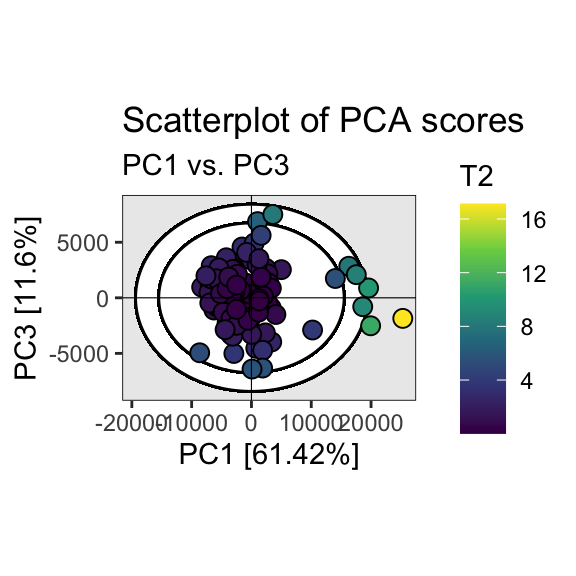

```r
pca_scores %>%
  ggplot(aes(x = Dim.1, y = Dim.3)) +
  geom_ellipse(aes(x0 = 0, y0 = 0, a = a1, b = b1, angle = 0), linewidth = .5, linetype = "solid", fill = "white") +
  geom_ellipse(aes(x0 = 0, y0 = 0, a = a2, b = b2, angle = 0), linewidth = .5, linetype = "solid", fill = "white") +
  geom_point(aes(fill = Tsq), shape = 21, size = 3, color = "black") +
  scale_fill_viridis_c(option = "viridis") +
  geom_hline(yintercept = 0, linetype = "solid", color = "black", linewidth = .2) +
  geom_vline(xintercept = 0, linetype = "solid", color = "black", linewidth = .2) +
  labs(
    title = "Scatterplot of PCA scores",
    subtitle = "PC1 vs. PC3",
    x = glue("PC1 [{t1}%]"),
    y = glue("PC3 [{t3}%]"),
    fill = "T2"
    ) +
  theme_grey() +
  theme(
    aspect.ratio = .7,
    panel.grid = element_blank(),
    panel.background = element_rect(
    colour = "black",
    linewidth = .3
    )
  )
```

## Calculating the x-y coordinates

In the example below, we focus on the subspace spanned by the 2nd and 3rd components.

```r
xy_coord <- ellipseCoord(pca_scores, pcx = 2, pcy = 3, conf.limit = 0.975, pts = 500)
```

```r
str(xy_coord)
```

```
#> tibble [500 × 2] (S3: tbl_df/tbl/data.frame)
#>  $ x: num [1:500] 9620 9620 9617 9613 9608 ...
#>  $ y: num [1:500] -3.22e-12 9.44e+01 1.89e+02 2.83e+02 3.77e+02 ...
```

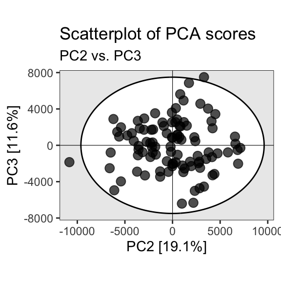

```r
ggplot() +
  geom_polygon(data = xy_coord, aes(x, y), color = "black", fill = "white") +
  geom_point(data = pca_scores, aes(x = Dim.2, y = Dim.3), shape = 21, size = 3, fill = "black", color = "black", alpha = 0.7) +
  geom_hline(yintercept = 0, linetype = "solid", color = "black", linewidth = .2) +
  geom_vline(xintercept = 0, linetype = "solid", color = "black", linewidth = .2) +
  labs(
    title = "Scatterplot of PCA scores",
    subtitle = "PC2 vs. PC3",
    x = glue("PC2 [{t2}%]"),
    y = glue("PC3 [{t3}%]")
    ) +
  theme_grey() +
  theme(
    aspect.ratio = .7,
    panel.grid = element_blank(),
    panel.background = element_rect(
    colour = "black",
    linewidth = .3
    )
  )
```

# Hotelling’s T-Squared Ellipsoid

The `ellipseCoord` function offers an optional parameter `pcz`. When activated, this parameter extends the function’s capabilities from two-dimensional ellipses to three-dimensional ellipsoids, providing a more comprehensive visualization of multivariate data, particularly in situation where the first two principal components do not adequately capture the data’s variability.

## Calculating the x-y-z coordinates

In the example below, the resulting 3D Hotelling’s T-squared ellipsoid serves as a volumetric confidence region in the subspace spanned by the 1st, 2nd, and 3rd components. It encapsulates a specified proportion of data points, determined by the confidence level, providing a more holistic view of the data’s distribution and outliers in three dimensions.

```r
xyz_coord <- ellipseCoord(pca_scores, pcx = 1, pcy = 2, pcz = 3, conf.limit = 0.95, pts = 100)
```

```r
str(xyz_coord)
```

```
#> tibble [10,000 × 3] (S3: tbl_df/tbl/data.frame)
#>  $ x: num [1:10000] 1.63e-11 1.63e-11 1.63e-11 1.63e-11 1.63e-11 ...
#>  $ y: num [1:10000] 1.87e-11 1.87e-11 1.87e-11 1.87e-11 1.87e-11 ...
#>  $ z: num [1:10000] 7745 7745 7745 7745 7745 ...
```

```r
T2 <- ellipseParam(pca_scores, k = 3)$Tsquare$value
```

```
color_palette <- viridisLite::viridis(nrow(pca_scores))
scaled_T2 <- scales::rescale(T2, to = c(1, nrow(pca_scores)))
point_colors <- color_palette[round(scaled_T2)]
```

```
rgl::setupKnitr(autoprint = TRUE)
rgl::plot3d(
  x = xyz_coord$x,
  y = xyz_coord$y,
  z = xyz_coord$z,
  xlab = "PC1",
  ylab = "PC2",
  zlab = "PC3",
  type = "l",
  lwd = 0.5,
  col = "lightgray",
  alpha = 0.5)
rgl::points3d(
  x = pca_scores$Dim.1,
  y = pca_scores$Dim.2,
  z = pca_scores$Dim.3,
  col = point_colors,
  size = 5,
  add = TRUE)
rgl::bgplot3d({
    par(mar = c(0,0,0,0))
    plot.new()
    color_legend <- as.raster(matrix(rev(color_palette), ncol = 1))
    rasterImage(color_legend, 0.85, 0.1, 0.9, 0.9)
    text(
      x = 0.92,
      y = seq(0.1, 0.9, length.out = 5),
      labels = round(seq(min(T2), max(T2), length.out = 5), 2),
      cex = 0.7)
    text(x = 0.92, y = 0.95, labels = "T2", cex = 0.8)})
rgl::view3d(theta = 30, phi = 25, zoom = .8)
```